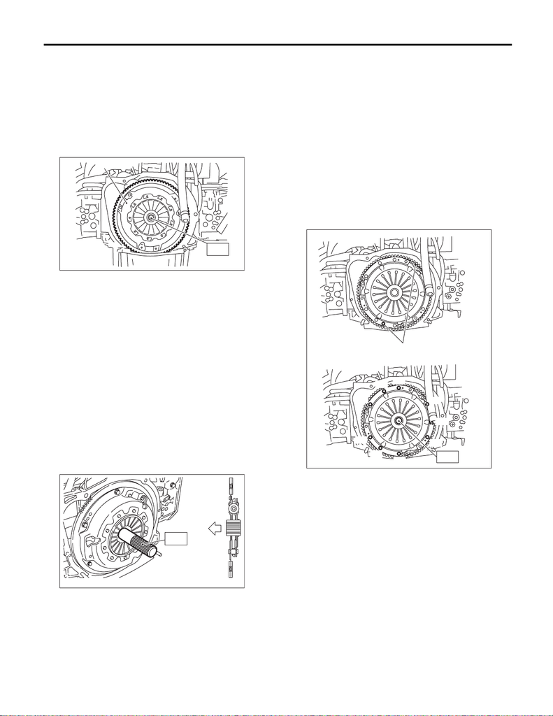

CL-12

Clutch Disc and Cover

CLUTCH SYSTEM

2. Clutch Disc and Cover

A: REMOVAL

1) Remove the transmission assembly from the ve-

hicle. <Ref. to 6MT(TY75)-25, REMOVAL, Manual

Transmission Assembly.> <Ref. to 6MT(TY85)-31,

REMOVAL, Manual Transmission Assembly.>

2) Attach the ST on the flywheel.

ST 499747100 CLUTCH DISC GUIDE

3) Remove the clutch cover and clutch disc.

NOTE:

• Take care not to allow oil to touch the clutch disc

face.

• Do not disassemble the clutch cover or clutch

disc.

B: INSTALLATION

1) Insert the ST into the clutch disc and attach to

the flywheel by inserting the ST end into pilot bear-

ing.

NOTE:

When installing the clutch disc, be careful to attach

in the correct direction.

ST 499747100 CLUTCH DISC GUIDE

2) Install the clutch cover to the flywheel and tight-

en the bolts to the specified torque.

NOTE:

• When installing a clutch cover to the flywheel,

position the clutch cover so that the spacing be-

tween the unbalance marks (paint mark) on the fly-

wheel and clutch cover is 120° or more apart. (The

unbalance mark indicates the direction of residual

unbalance.)

• Temporarily tighten the bolts by hand. Each bolt

should be tightened to the specified torque in a

crisscross order.

Tightening torque:

16 N·m (1.6 kgf-m, 11.8 ft-lb)

• STI model

(A) Clutch cover

(A) Flywheel side

CL-00011

(A)

ST

CL-00208

(A)

ST

(A) Unbalance mark (paint)

CL-00792

(A)

ST

(2)

(5)

(3)

(1)

(6)

(4)

(7)

(8)

(9)

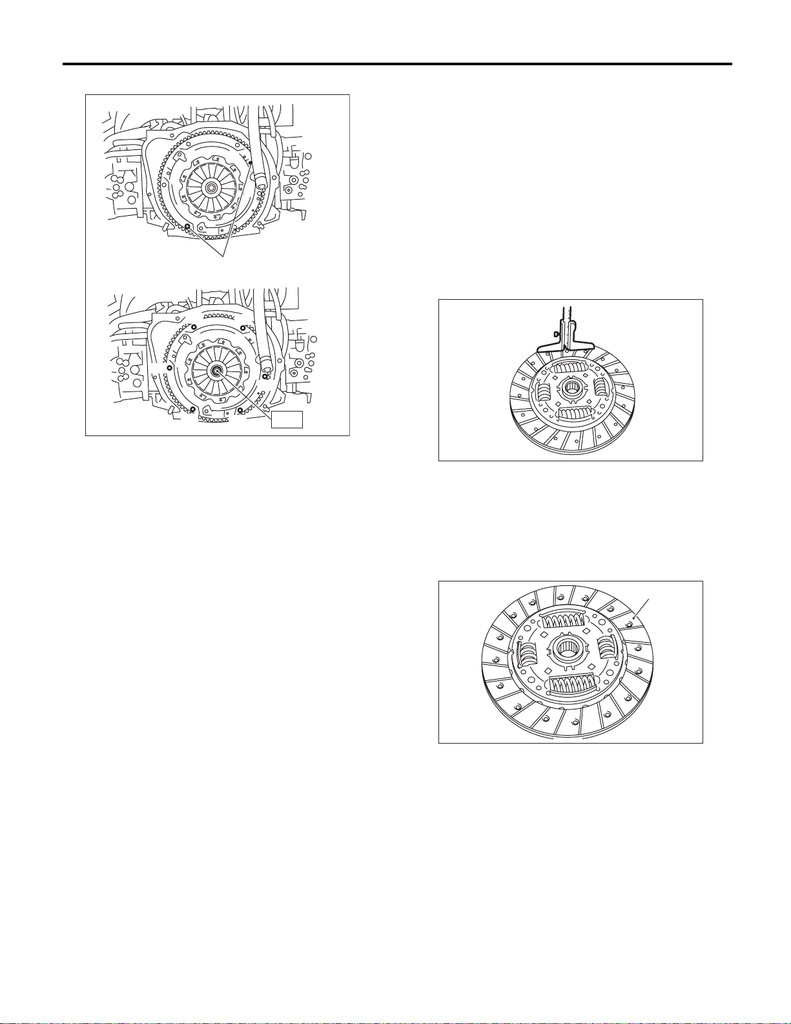

CL-13

Clutch Disc and Cover

CLUTCH SYSTEM

• Except for STI model

3) Remove the ST.

ST 499747100 CLUTCH DISC GUIDE

4) Install the transmission assembly. <Ref. to

6MT(TY75)-30, INSTALLATION, Manual Trans-

mission Assembly.> <Ref. to 6MT(TY85)-33, IN-

STALLATION, Manual Transmission Assembly.>

C: INSPECTION

1. CLUTCH DISC

1) Facing wear

Measure the depth from the facing surface to the

rivet head. Replace if the face is worn locally or

worn down to less than the specified value.

Depth to rivet head:

Limit of sinking

0.8 mm (0.031 in)

NOTE:

Do not wash the clutch disc with any type of clean-

ing fluid.

2) Hardened facing

Replace the clutch disc.

3) Oil soakage on facing

Replace the clutch disc and inspect the transmis-

sion front oil seal, transmission case mating sur-

face, engine rear oil seal and other locations for oil

leakage.

(A) Unbalance mark (paint)

CL-00013

(A)

ST

(2)

(5)

(3)

(1)

(6)

(4)

(A) Clutch facing

CL-00014

CL-00015

(A)

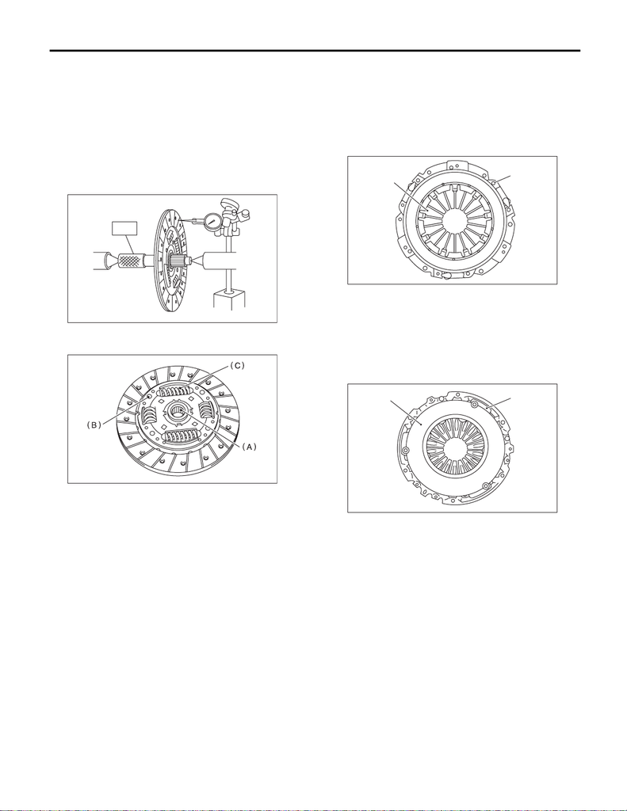

CL-14

Clutch Disc and Cover

CLUTCH SYSTEM

4) Deflection on facing

If deflection exceeds the specified value at the out-

er circumference of the facing, replace the clutch

disc.

ST 499747100 CLUTCH DISC GUIDE

Limit for deflection:

STI model

0.7 mm (0.028 in) at R = 115 mm (4.53 in)

Except for STI model

0.7 mm (0.028 in) at R = 110 mm (4.33 in)

5) If there is spline wear, loose rivets, failed damper

springs, etc., replace the clutch disc.

2. CLUTCH COVER

NOTE:

Visually check the following items without disas-

sembling, and replace or repair if defective.

1) Loose thrust rivet

2) Damaged or worn bearing contact area at the

center of diaphragm spring

3) Damaged or worn disc contact surface of the

pressure plate

4) Loose strap plate installation area

5) Worn diaphragm sliding area

(A) Spline

(B) Rivet

(C) Damper spring

CL-00016

ST

CL-00017

(A) Thrust rivet

(B) Diaphragm spring

(A) Pressure plate

(B) Strap plate

CL-00018

(A)

(B)

CL-00176

(A)

(B)